# Regression-Gradient Transport On Quadric Hypersurfaces

# Purpose

This report validates the coordinate-based regression-gradient transported Hessian on data-derived graphs sampled from quadratic graph hypersurfaces. The sampled points have intrinsic coordinates

$$u=(u_1,\ldots,u_m)\in \mathbb R^m$$

and ambient data coordinates

$$\Phi(u)=\bigl(u,\ q(u)\bigr), \qquad
q(u)=\sum_{i=1}^{k} c_i u_i^2-\sum_{i=k+1}^{m} c_i u_i^2.$$

The graph is built as a connected symmetric kNN graph in the ambient data coordinates $\Phi(u)$. The operator is always fit with

```r
transport.rule = "regression.gradient"
gradient.coordinate.method = "coordinates"
```

but we compare three coordinate sources passed to the gradient regression: the intrinsic chart $u$, the ambient data matrix $\Phi(u)$, and a PCA projection of $\Phi(u)$ to the known intrinsic dimension.

The crucial point is that the probes are always intrinsic polynomials:

$$1,\quad u_i,\quad u_i u_j.$$

Thus the primary test asks whether the operator behaves like an intrinsic second-difference-like construction even when it receives ambient data coordinates.

**Build:** 2026-05-19 04:13:58 EDT  
**Mode:** full  
**Runs:** 192  
**Cases:** 32

# Affine Intrinsic Probes

The primary diagnostic is the mean residual over intrinsic affine probes:

$$R_{\mathrm{aff}}
=
\frac{1}{m}\sum_{i=1}^m
\frac{\|A u_i\|_2}{\|u_i\|_2}.$$

For an intrinsic Hessian-like operator this should be small. Curvature tests whether ambient data coordinates remain reliable as the surface bends away from its parameter plane.

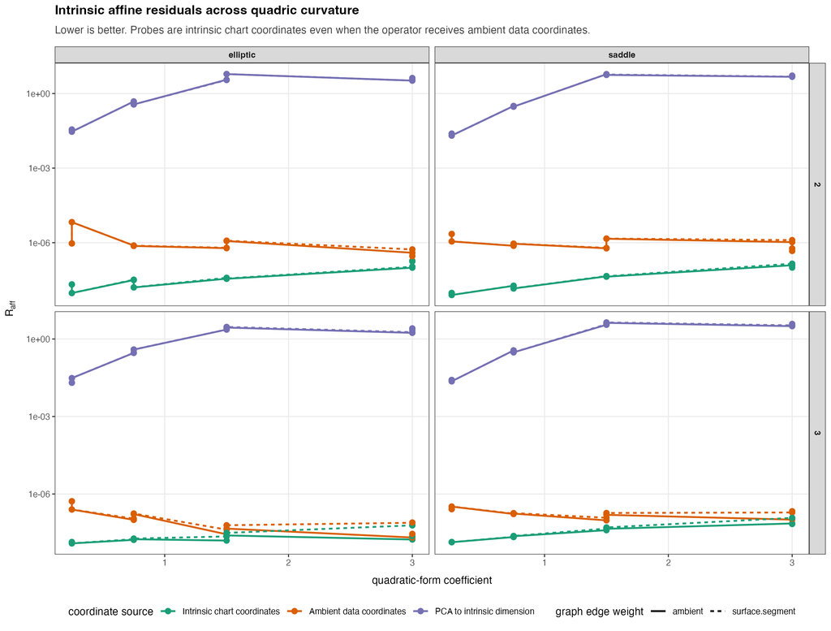

The intrinsic-coordinate curve is the oracle reference. The ambient-coordinate curve is the practical data-matrix case. A widening gap between the two as curvature increases indicates curvature bias in the local ambient-coordinate gradient regression.

# Quadratic Intrinsic Probes

For this second-difference-like operator, intrinsic quadratic probes should not be annihilated. The mean quadratic residual is

$$R_{\mathrm{quad}}
=
\frac{1}{|\mathcal Q|}
\sum_{i\le j}
\frac{\|A(u_i u_j)\|_2}{\|u_i u_j\|_2}.$$

If both affine and quadratic residuals vanish, the operator is too weak.

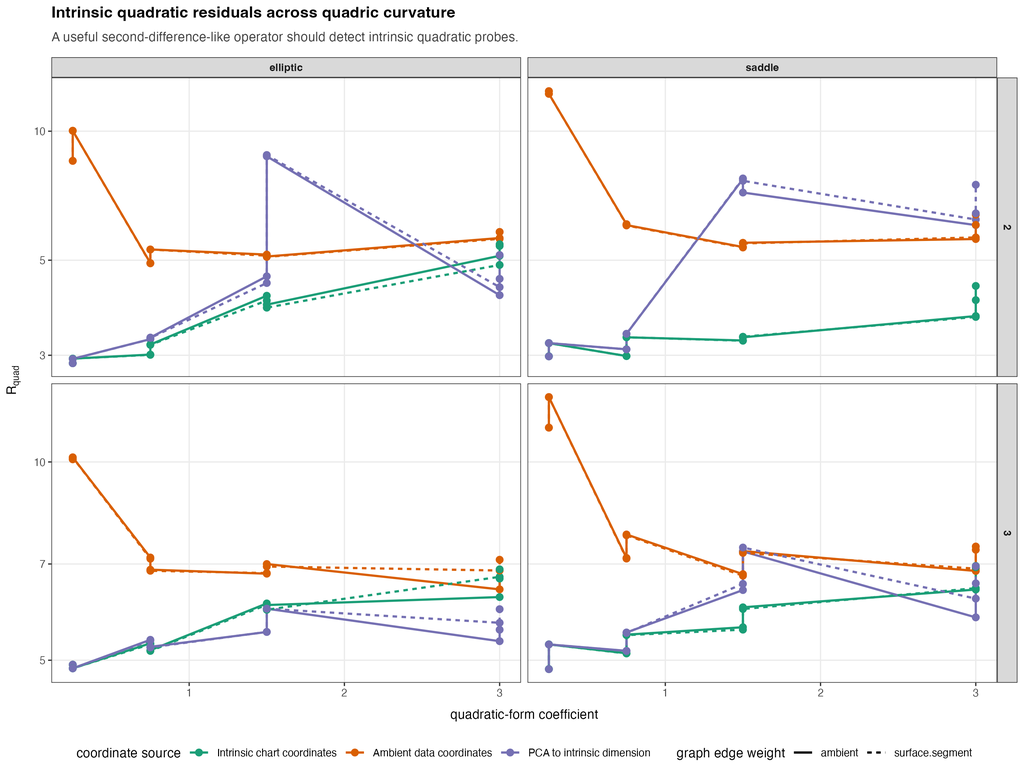

# Ambient Versus Intrinsic Gap

The ratio

$$\frac{R_{\mathrm{aff}}(\mathrm{ambient})}
{R_{\mathrm{aff}}(\mathrm{intrinsic})}$$

summarizes the penalty for using the available data coordinates instead of the unobserved intrinsic chart. Values near one mean ambient coordinates are essentially as good as the intrinsic oracle. Large values indicate curvature or sampling effects.

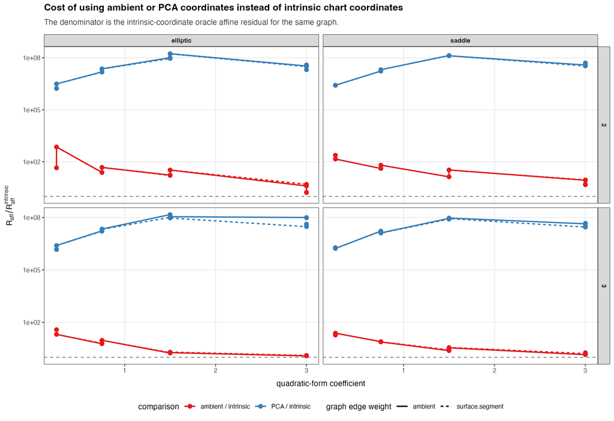

# Local Gradient Conditioning

Regression-gradient transport depends on local weighted least-squares gradient fits. The next diagnostic shows whether poor affine residuals coincide with rank deficiency or ill conditioning.

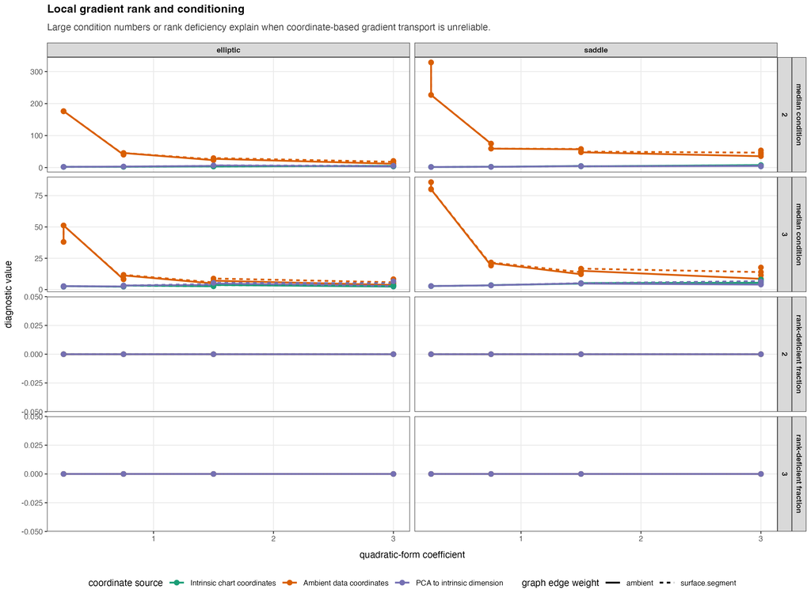

# Results Summary

Median diagnostics by intrinsic dimension, coordinate source, and graph edge weight.

| intrinsic.dim | coordinate.source | graph.weight | residual.linear.mean | residual.quadratic.mean | rank.deficient.fraction | median.local.condition |
| --- | --- | --- | --- | --- | --- | --- |
| 2 | ambient | ambient | 0.0000 | 5.7254 | 0 | 46.6058 |
| 3 | ambient | ambient | 0.0000 | 7.1550 | 0 | 11.8591 |
| 2 | intrinsic | ambient | 0.0000 | 3.2761 | 0 | 2.9254 |
| 3 | intrinsic | ambient | 0.0000 | 5.5391 | 0 | 3.0534 |
| 2 | pca_intrinsic_dim | ambient | 1.9005 | 3.7544 | 0 | 3.2431 |
| 3 | pca_intrinsic_dim | ambient | 1.0580 | 5.4399 | 0 | 3.3284 |
| 2 | ambient | surface.segment | 0.0000 | 5.7349 | 0 | 51.8011 |
| 3 | ambient | surface.segment | 0.0000 | 7.1319 | 0 | 15.3499 |
| 2 | intrinsic | surface.segment | 0.0000 | 3.2743 | 0 | 2.9013 |
| 3 | intrinsic | surface.segment | 0.0000 | 5.5114 | 0 | 3.2517 |
| 2 | pca_intrinsic_dim | surface.segment | 1.9020 | 3.8464 | 0 | 3.5747 |
| 3 | pca_intrinsic_dim | surface.segment | 1.1112 | 5.5111 | 0 | 3.9588 |

## What We Learned

The validation used 192 successful runs over 32 quadric cases. The intrinsic-chart coordinate source is the oracle reference, while ambient coordinates are the practical data-derived graph setting.

The median intrinsic affine residual was 3.6e-07 for ambient coordinates, 2.34e-08 for intrinsic coordinates, and 1.1 for PCA coordinates. These numbers should be read against the quadratic residuals, whose medians were 6.85, 4.87, and 5.26 respectively.

The ambient-coordinate residual is larger than the intrinsic oracle because the ambient coordinates contain the curved coordinate q(u), and the local weighted least-squares systems are more ill-conditioned. The median local condition number was 32.6 for ambient coordinates versus 3.19 for intrinsic coordinates. Even so, the ambient affine residual remains near zero on the absolute scale, while quadratic residuals remain clearly nonzero.

The PCA-to-intrinsic-dimension coordinate source is not a winner in this experiment. It is a linear projection of the curved ambient data, not a recovered intrinsic chart, and it does not preserve the intrinsic coordinate functions used as probes. Its large affine residuals should be interpreted as a warning against assuming that a low-dimensional PCA projection is automatically an intrinsic chart.

Ambient and exact surface-segment graph edge weights gave nearly the same qualitative conclusions. In this validation, the dominant factor is the coordinate source supplied to the regression-gradient fit, not the small distinction between ambient Euclidean edge weights and quadratic-surface segment weights on retained kNN edges.

The main practical interpretation is positive: for data-derived kNN graphs whose vertices retain their original data matrix coordinates, supplied-coordinate regression-gradient transport behaves like the clear target method. The next validation should add noise, nonuniform sampling, and higher-dimensional PCA settings to determine when raw data coordinates should be replaced by local tangent coordinates.

# Appendix

## Summary Table

| case.id | intrinsic.dim | surface | curvature | n | seed | k | index.k | graph.weight | coordinate.source | coordinate.label | coordinate.dim | status | runtime.sec | n.edges | n.mst.edges.added | n.rows | nullity.estimate | median.local.rank | min.local.rank | rank.deficient.fraction | median.local.condition | message | residual.constant | residual.linear.mean | residual.linear.max | residual.quadratic.mean | residual.quadratic.min | residual.overall |
| --- | --- | --- | --- | --- | --- | --- | --- | --- | --- | --- | --- | --- | --- | --- | --- | --- | --- | --- | --- | --- | --- | --- | --- | --- | --- | --- | --- | --- |
| quadric_2d_elliptic_c0.25_n70_seed121 | 2 | elliptic | 0.25 | 70 | 121 | 8 | 2 | ambient | intrinsic | Intrinsic chart coordinates | 2 | ok | 1.220 | 348 | 0 | 1392 | 1 | 2 | 2 | 0 | 2.10749 | NA | 0 | 0.00000 | 0.00000 | 2.87493 | 2.57970 | 1.42923 |
| quadric_2d_elliptic_c0.25_n70_seed121 | 2 | elliptic | 0.25 | 70 | 121 | 8 | 2 | ambient | ambient | Ambient data coordinates | 3 | ok | 1.206 | 348 | 0 | 2088 | 1 | 3 | 3 | 0 | 175.65555 | NA | 0 | 0.00000 | 0.00000 | 8.52900 | 8.13315 | 4.19209 |
| quadric_2d_elliptic_c0.25_n70_seed121 | 2 | elliptic | 0.25 | 70 | 121 | 8 | 2 | ambient | pca_intrinsic_dim | PCA to intrinsic dimension | 2 | ok | 0.774 | 348 | 0 | 1392 | 1 | 2 | 2 | 0 | 2.12352 | NA | 0 | 0.03568 | 0.04977 | 2.87381 | 2.58050 | 1.42875 |
| quadric_2d_elliptic_c0.25_n70_seed121 | 2 | elliptic | 0.25 | 70 | 121 | 8 | 2 | surface.segment | intrinsic | Intrinsic chart coordinates | 2 | ok | 0.775 | 348 | 0 | 1392 | 1 | 2 | 2 | 0 | 2.10605 | NA | 0 | 0.00000 | 0.00000 | 2.87502 | 2.57996 | 1.42927 |
| quadric_2d_elliptic_c0.25_n70_seed121 | 2 | elliptic | 0.25 | 70 | 121 | 8 | 2 | surface.segment | ambient | Ambient data coordinates | 3 | ok | 1.156 | 348 | 0 | 2088 | 1 | 3 | 3 | 0 | 175.97716 | NA | 0 | 0.00000 | 0.00000 | 8.52557 | 8.12992 | 4.19041 |
| quadric_2d_elliptic_c0.25_n70_seed121 | 2 | elliptic | 0.25 | 70 | 121 | 8 | 2 | surface.segment | pca_intrinsic_dim | PCA to intrinsic dimension | 2 | ok | 0.860 | 348 | 0 | 1392 | 1 | 2 | 2 | 0 | 2.12568 | NA | 0 | 0.03568 | 0.04977 | 2.87389 | 2.58078 | 1.42878 |
| quadric_2d_elliptic_c0.25_n70_seed222 | 2 | elliptic | 0.25 | 70 | 222 | 8 | 2 | ambient | intrinsic | Intrinsic chart coordinates | 2 | ok | 0.707 | 329 | 0 | 1316 | 1 | 2 | 2 | 0 | 2.16958 | NA | 0 | 0.00000 | 0.00000 | 2.94644 | 2.55706 | 1.41286 |
| quadric_2d_elliptic_c0.25_n70_seed222 | 2 | elliptic | 0.25 | 70 | 222 | 8 | 2 | ambient | ambient | Ambient data coordinates | 3 | ok | 1.055 | 329 | 0 | 1974 | 1 | 3 | 3 | 0 | 176.48221 | NA | 0 | 0.00001 | 0.00001 | 10.02508 | 8.82015 | 4.94983 |
| quadric_2d_elliptic_c0.25_n70_seed222 | 2 | elliptic | 0.25 | 70 | 222 | 8 | 2 | ambient | pca_intrinsic_dim | PCA to intrinsic dimension | 2 | ok | 0.720 | 329 | 0 | 1316 | 1 | 2 | 2 | 0 | 2.17025 | NA | 0 | 0.02929 | 0.03468 | 2.94184 | 2.55114 | 1.41100 |
| quadric_2d_elliptic_c0.25_n70_seed222 | 2 | elliptic | 0.25 | 70 | 222 | 8 | 2 | surface.segment | intrinsic | Intrinsic chart coordinates | 2 | ok | 0.738 | 329 | 0 | 1316 | 1 | 2 | 2 | 0 | 2.16656 | NA | 0 | 0.00000 | 0.00000 | 2.94638 | 2.55654 | 1.41282 |
| quadric_2d_elliptic_c0.25_n70_seed222 | 2 | elliptic | 0.25 | 70 | 222 | 8 | 2 | surface.segment | ambient | Ambient data coordinates | 3 | ok | 1.077 | 329 | 0 | 1974 | 1 | 3 | 3 | 0 | 176.54469 | NA | 0 | 0.00001 | 0.00001 | 10.02322 | 8.81671 | 4.94910 |
| quadric_2d_elliptic_c0.25_n70_seed222 | 2 | elliptic | 0.25 | 70 | 222 | 8 | 2 | surface.segment | pca_intrinsic_dim | PCA to intrinsic dimension | 2 | ok | 0.808 | 329 | 0 | 1316 | 1 | 2 | 2 | 0 | 2.16733 | NA | 0 | 0.02930 | 0.03468 | 2.94175 | 2.55063 | 1.41094 |
| quadric_2d_elliptic_c0.75_n70_seed121 | 2 | elliptic | 0.75 | 70 | 121 | 8 | 2 | ambient | intrinsic | Intrinsic chart coordinates | 2 | ok | 0.764 | 351 | 0 | 1404 | 1 | 2 | 2 | 0 | 2.26605 | NA | 0 | 0.00000 | 0.00000 | 3.01087 | 2.82559 | 1.49623 |
| quadric_2d_elliptic_c0.75_n70_seed121 | 2 | elliptic | 0.75 | 70 | 121 | 8 | 2 | ambient | ambient | Ambient data coordinates | 3 | ok | 1.202 | 351 | 0 | 2106 | 1 | 3 | 3 | 0 | 40.11947 | NA | 0 | 0.00000 | 0.00000 | 4.92435 | 4.79453 | 2.43565 |
| quadric_2d_elliptic_c0.75_n70_seed121 | 2 | elliptic | 0.75 | 70 | 121 | 8 | 2 | ambient | pca_intrinsic_dim | PCA to intrinsic dimension | 2 | ok | 0.768 | 351 | 0 | 1404 | 1 | 2 | 2 | 0 | 3.01586 | NA | 0 | 0.47973 | 0.67771 | 3.27151 | 2.86846 | 1.64756 |
| quadric_2d_elliptic_c0.75_n70_seed121 | 2 | elliptic | 0.75 | 70 | 121 | 8 | 2 | surface.segment | intrinsic | Intrinsic chart coordinates | 2 | ok | 0.763 | 351 | 0 | 1404 | 1 | 2 | 2 | 0 | 2.24894 | NA | 0 | 0.00000 | 0.00000 | 3.00666 | 2.82473 | 1.49390 |
| quadric_2d_elliptic_c0.75_n70_seed121 | 2 | elliptic | 0.75 | 70 | 121 | 8 | 2 | surface.segment | ambient | Ambient data coordinates | 3 | ok | 1.152 | 351 | 0 | 2106 | 1 | 3 | 3 | 0 | 40.82254 | NA | 0 | 0.00000 | 0.00000 | 4.91648 | 4.78780 | 2.43169 |
| quadric_2d_elliptic_c0.75_n70_seed121 | 2 | elliptic | 0.75 | 70 | 121 | 8 | 2 | surface.segment | pca_intrinsic_dim | PCA to intrinsic dimension | 2 | ok | 0.771 | 351 | 0 | 1404 | 1 | 2 | 2 | 0 | 3.00757 | NA | 0 | 0.48048 | 0.67877 | 3.27010 | 2.86577 | 1.64696 |
| quadric_2d_elliptic_c0.75_n70_seed222 | 2 | elliptic | 0.75 | 70 | 222 | 8 | 2 | ambient | intrinsic | Intrinsic chart coordinates | 2 | ok | 0.757 | 336 | 0 | 1344 | 1 | 2 | 2 | 0 | 2.45942 | NA | 0 | 0.00000 | 0.00000 | 3.17804 | 3.01109 | 1.53977 |
| quadric_2d_elliptic_c0.75_n70_seed222 | 2 | elliptic | 0.75 | 70 | 222 | 8 | 2 | ambient | ambient | Ambient data coordinates | 3 | ok | 1.188 | 336 | 0 | 2016 | 1 | 3 | 3 | 0 | 45.45447 | NA | 0 | 0.00000 | 0.00000 | 5.29700 | 4.72350 | 2.55728 |
| quadric_2d_elliptic_c0.75_n70_seed222 | 2 | elliptic | 0.75 | 70 | 222 | 8 | 2 | ambient | pca_intrinsic_dim | PCA to intrinsic dimension | 2 | ok | 0.731 | 336 | 0 | 1344 | 1 | 2 | 2 | 0 | 3.16118 | NA | 0 | 0.36496 | 0.44614 | 3.29978 | 2.97704 | 1.60502 |
| quadric_2d_elliptic_c0.75_n70_seed222 | 2 | elliptic | 0.75 | 70 | 222 | 8 | 2 | surface.segment | intrinsic | Intrinsic chart coordinates | 2 | ok | 0.752 | 336 | 0 | 1344 | 1 | 2 | 2 | 0 | 2.44717 | NA | 0 | 0.00000 | 0.00000 | 3.17232 | 3.00015 | 1.53657 |
| quadric_2d_elliptic_c0.75_n70_seed222 | 2 | elliptic | 0.75 | 70 | 222 | 8 | 2 | surface.segment | ambient | Ambient data coordinates | 3 | ok | 1.087 | 336 | 0 | 2016 | 1 | 3 | 3 | 0 | 45.67585 | NA | 0 | 0.00000 | 0.00000 | 5.29417 | 4.72473 | 2.55661 |
| quadric_2d_elliptic_c0.75_n70_seed222 | 2 | elliptic | 0.75 | 70 | 222 | 8 | 2 | surface.segment | pca_intrinsic_dim | PCA to intrinsic dimension | 2 | ok | 0.752 | 336 | 0 | 1344 | 1 | 2 | 2 | 0 | 3.15049 | NA | 0 | 0.36477 | 0.44592 | 3.29344 | 2.96711 | 1.60164 |
| quadric_2d_elliptic_c1.50_n70_seed121 | 2 | elliptic | 1.50 | 70 | 121 | 8 | 2 | ambient | intrinsic | Intrinsic chart coordinates | 2 | ok | 0.773 | 352 | 0 | 1408 | 1 | 2 | 2 | 0 | 3.65772 | NA | 0 | 0.00000 | 0.00000 | 4.13089 | 3.64986 | 2.07148 |
| quadric_2d_elliptic_c1.50_n70_seed121 | 2 | elliptic | 1.50 | 70 | 121 | 8 | 2 | ambient | ambient | Ambient data coordinates | 3 | ok | 1.269 | 352 | 0 | 2112 | 1 | 3 | 3 | 0 | 23.11514 | NA | 0 | 0.00000 | 0.00000 | 5.15315 | 4.99283 | 2.54320 |
| quadric_2d_elliptic_c1.50_n70_seed121 | 2 | elliptic | 1.50 | 70 | 121 | 8 | 2 | ambient | pca_intrinsic_dim | PCA to intrinsic dimension | 2 | ok | 0.768 | 352 | 0 | 1408 | 1 | 2 | 2 | 0 | 5.10064 | NA | 0 | 3.60933 | 5.47639 | 4.58511 | 3.61830 | 3.12371 |
| quadric_2d_elliptic_c1.50_n70_seed121 | 2 | elliptic | 1.50 | 70 | 121 | 8 | 2 | surface.segment | intrinsic | Intrinsic chart coordinates | 2 | ok | 0.761 | 352 | 0 | 1408 | 1 | 2 | 2 | 0 | 3.63470 | NA | 0 | 0.00000 | 0.00000 | 4.02505 | 3.60240 | 2.01450 |
| quadric_2d_elliptic_c1.50_n70_seed121 | 2 | elliptic | 1.50 | 70 | 121 | 8 | 2 | surface.segment | ambient | Ambient data coordinates | 3 | ok | 1.143 | 352 | 0 | 2112 | 1 | 3 | 3 | 0 | 25.75091 | NA | 0 | 0.00000 | 0.00000 | 5.12317 | 4.95912 | 2.52776 |
| quadric_2d_elliptic_c1.50_n70_seed121 | 2 | elliptic | 1.50 | 70 | 121 | 8 | 2 | surface.segment | pca_intrinsic_dim | PCA to intrinsic dimension | 2 | ok | 0.773 | 352 | 0 | 1408 | 1 | 2 | 2 | 0 | 5.32878 | NA | 0 | 3.50577 | 5.31927 | 4.42317 | 3.58909 | 3.02276 |

[output cut: 162 more lines]

## Gradient Diagnostics

| vertex | n.local | rank | condition | case.id | intrinsic.dim | surface | curvature | graph.weight | coordinate.source |
| --- | --- | --- | --- | --- | --- | --- | --- | --- | --- |
| 1 | 9 | 2 | 1.40765 | quadric_2d_elliptic_c0.25_n70_seed121 | 2 | elliptic | 0.25 | ambient | intrinsic |
| 2 | 8 | 2 | 1.47229 | quadric_2d_elliptic_c0.25_n70_seed121 | 2 | elliptic | 0.25 | ambient | intrinsic |
| 3 | 12 | 2 | 1.38557 | quadric_2d_elliptic_c0.25_n70_seed121 | 2 | elliptic | 0.25 | ambient | intrinsic |
| 4 | 9 | 2 | 6.86426 | quadric_2d_elliptic_c0.25_n70_seed121 | 2 | elliptic | 0.25 | ambient | intrinsic |
| 5 | 12 | 2 | 1.09731 | quadric_2d_elliptic_c0.25_n70_seed121 | 2 | elliptic | 0.25 | ambient | intrinsic |
| 6 | 11 | 2 | 1.26257 | quadric_2d_elliptic_c0.25_n70_seed121 | 2 | elliptic | 0.25 | ambient | intrinsic |
| 7 | 9 | 2 | 1.64362 | quadric_2d_elliptic_c0.25_n70_seed121 | 2 | elliptic | 0.25 | ambient | intrinsic |
| 8 | 8 | 2 | 2.55491 | quadric_2d_elliptic_c0.25_n70_seed121 | 2 | elliptic | 0.25 | ambient | intrinsic |
| 9 | 11 | 2 | 4.20784 | quadric_2d_elliptic_c0.25_n70_seed121 | 2 | elliptic | 0.25 | ambient | intrinsic |
| 10 | 12 | 2 | 1.17898 | quadric_2d_elliptic_c0.25_n70_seed121 | 2 | elliptic | 0.25 | ambient | intrinsic |
| 11 | 8 | 2 | 1.55824 | quadric_2d_elliptic_c0.25_n70_seed121 | 2 | elliptic | 0.25 | ambient | intrinsic |
| 12 | 11 | 2 | 1.10787 | quadric_2d_elliptic_c0.25_n70_seed121 | 2 | elliptic | 0.25 | ambient | intrinsic |
| 13 | 13 | 2 | 1.36603 | quadric_2d_elliptic_c0.25_n70_seed121 | 2 | elliptic | 0.25 | ambient | intrinsic |
| 14 | 8 | 2 | 2.47683 | quadric_2d_elliptic_c0.25_n70_seed121 | 2 | elliptic | 0.25 | ambient | intrinsic |
| 15 | 8 | 2 | 2.83401 | quadric_2d_elliptic_c0.25_n70_seed121 | 2 | elliptic | 0.25 | ambient | intrinsic |
| 16 | 14 | 2 | 1.12881 | quadric_2d_elliptic_c0.25_n70_seed121 | 2 | elliptic | 0.25 | ambient | intrinsic |
| 17 | 9 | 2 | 5.49306 | quadric_2d_elliptic_c0.25_n70_seed121 | 2 | elliptic | 0.25 | ambient | intrinsic |
| 18 | 9 | 2 | 1.22447 | quadric_2d_elliptic_c0.25_n70_seed121 | 2 | elliptic | 0.25 | ambient | intrinsic |
| 19 | 12 | 2 | 2.15928 | quadric_2d_elliptic_c0.25_n70_seed121 | 2 | elliptic | 0.25 | ambient | intrinsic |
| 20 | 9 | 2 | 7.27024 | quadric_2d_elliptic_c0.25_n70_seed121 | 2 | elliptic | 0.25 | ambient | intrinsic |
| 21 | 8 | 2 | 3.45638 | quadric_2d_elliptic_c0.25_n70_seed121 | 2 | elliptic | 0.25 | ambient | intrinsic |
| 22 | 8 | 2 | 13.67362 | quadric_2d_elliptic_c0.25_n70_seed121 | 2 | elliptic | 0.25 | ambient | intrinsic |
| 23 | 11 | 2 | 2.99715 | quadric_2d_elliptic_c0.25_n70_seed121 | 2 | elliptic | 0.25 | ambient | intrinsic |
| 24 | 10 | 2 | 1.14894 | quadric_2d_elliptic_c0.25_n70_seed121 | 2 | elliptic | 0.25 | ambient | intrinsic |
| 25 | 14 | 2 | 1.34405 | quadric_2d_elliptic_c0.25_n70_seed121 | 2 | elliptic | 0.25 | ambient | intrinsic |
| 26 | 11 | 2 | 1.44365 | quadric_2d_elliptic_c0.25_n70_seed121 | 2 | elliptic | 0.25 | ambient | intrinsic |
| 27 | 13 | 2 | 1.61181 | quadric_2d_elliptic_c0.25_n70_seed121 | 2 | elliptic | 0.25 | ambient | intrinsic |
| 28 | 8 | 2 | 10.02663 | quadric_2d_elliptic_c0.25_n70_seed121 | 2 | elliptic | 0.25 | ambient | intrinsic |
| 29 | 11 | 2 | 1.76746 | quadric_2d_elliptic_c0.25_n70_seed121 | 2 | elliptic | 0.25 | ambient | intrinsic |
| 30 | 8 | 2 | 4.07804 | quadric_2d_elliptic_c0.25_n70_seed121 | 2 | elliptic | 0.25 | ambient | intrinsic |

[output cut: 170 more lines]

## Reproduction Command

```r
# Smoke:
# Rscript dev/graph-trend-filtering/render_transported_hessian_quadric_coordinate_validation.R
#
# Full:
# GFLOW_QUADRIC_COORDINATE_VALIDATION_MODE=full \
#   Rscript dev/graph-trend-filtering/render_transported_hessian_quadric_coordinate_validation.R
```